# Replication of “Anti-Immigrant Rhetoric and ICE Reporting Interest: Evidence from a Large-Scale Study of Web Search Data”

Suvedei Soyol-Erdene (Baruch College) and Eric Guan (Hunter College)

7/6/2024

```r
# Loading in all datasets used for replication

# Dataset downloaded from Google Trends 2024
google_trends_2024 <- read.csv("data/from_google_trends_2024/google_trend_search.csv", header = FALSE, col.names = c("ym", "report", "crime", "welfare"))

google_trends_2024 <- google_trends_2024[-c(1, 2), ] %>%  mutate(ym = ym(ym), report = as.numeric(report), crime = as.numeric(crime), welfare = as.numeric(welfare)) %>% filter(ym < ym("2020-01"))

google_trends_2024 <- google_trends_2024 %>% mutate( president = case_when(
  ym < ym("2009-01") ~ "Bush" ,
  ym < ym("2017-01") ~ "Obama" ,
  .default = "Trump"))


# Original dataset used in the paper
original_crime <- read.csv("data/from_replication_files/google_trends_crime.csv", col.names = c("year", "month", "crime")) %>%
  unite(date,c(year, month), sep = "-")
original_report <- read.csv("data/from_replication_files/google_trends_report.csv" , col.names = c("year", "month", "report")) %>%
unite(date,c(year, month), sep = "-")
original_welfare <- read.csv("data/from_replication_files/google_trends_welfare.csv", col.names = c("year", "month", "welfare")) %>%
                         unite(date,c(year, month), sep = "-")

trends_original <- left_join(original_crime, original_report, by = join_by(date)) %>%
  left_join(original_welfare, by = join_by(date)) %>%
  mutate(date = ym(date))

trends_original <- trends_original %>% mutate( president = case_when(
  date < ym("2009-01") ~ "Bush" ,
  date < ym("2017-01") ~ "Obama" ,
  .default = "Trump"))


# Import the topic model
library(stm)
load("data/topic_model_lite.RData")

# Import Daily Google Trends dataset
daily_report <- read.csv(("data/from_replication_files/gt_report_daily.csv")) %>%
  mutate(ymd = ymd(date)) %>%
  select(ymd, search, search_adj)
```

# Figure 4 Replication: Google Trend data split by Presidential Term

## Replication of Figure 4 using 2024 Google Trends Data

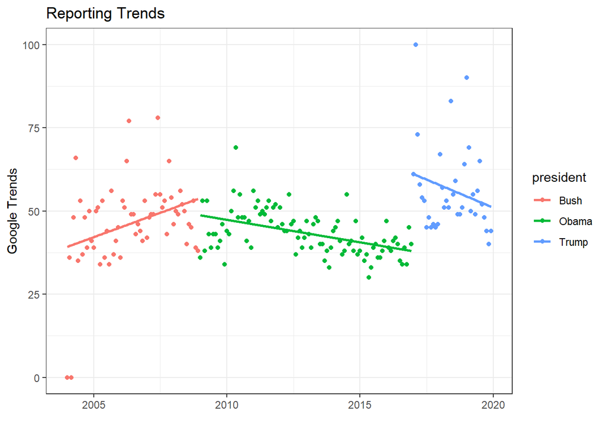

```r
#plotting reporting
google_trends_2024  %>%
  ggplot(aes(x = ym, y = report, color =  president), group_by = president) +
  geom_point() + geom_smooth(method = "lm", se = FALSE) +
  ylab("Google Trends")  +
  xlab("") +
  ggtitle("Reporting Trends")
```

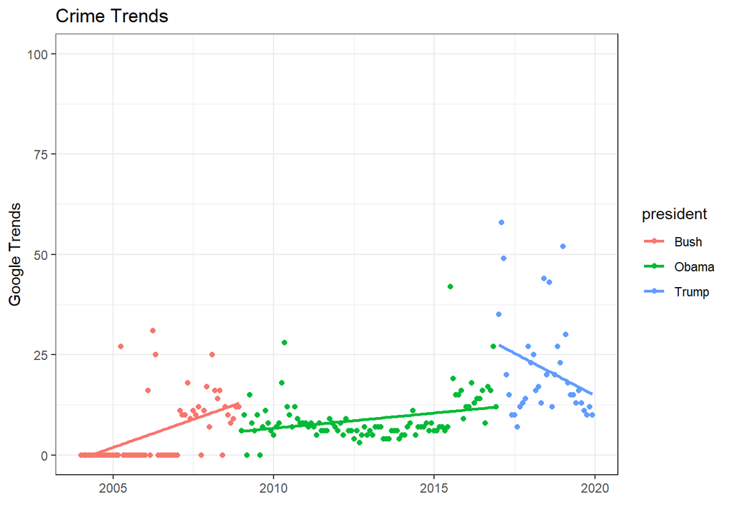

```r
#plotting crime
google_trends_2024  %>%
  ggplot(aes(x = ym, y = crime, color =  president), group_by = president) +
  geom_point() + geom_smooth(method = "lm", se = FALSE) +
  ylab("Google Trends") + xlab("") +
  scale_y_continuous(limits = c(0, 100)) +
  ggtitle("Crime Trends")
```

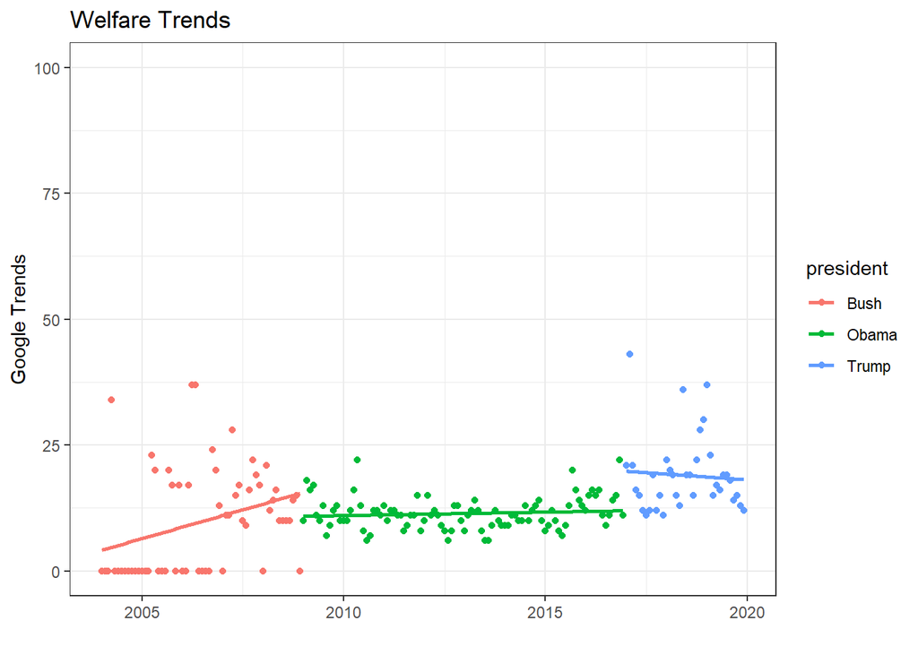

```r
#plotting welfare
google_trends_2024  %>%
  ggplot(aes(x = ym, y = welfare, color =  president), group_by = president) +
  geom_point() + geom_smooth(method = "lm", se = FALSE) +
  ylab("Google Trends") + xlab("") + scale_y_continuous(limits = c(0, 100)) +
  ggtitle("Welfare Trends")
```

## Replication of Figure 4 using the Original Dataset

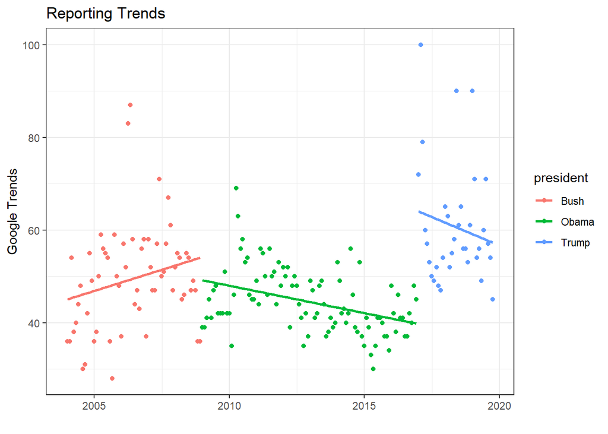

```r
#plotting reporting
trends_original  %>%
  ggplot(aes(x = date, y = report, color =  president), group_by = president) +
  geom_point() + geom_smooth(method = "lm", se = FALSE) +
  ylab("Google Trends")  +
  xlab("") +
  ggtitle("Reporting Trends")
```

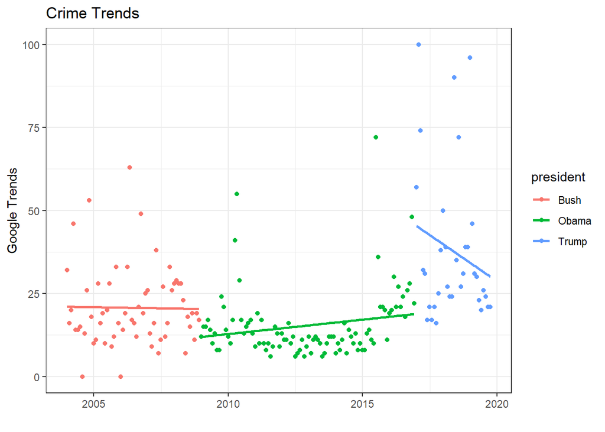

```r
#plotting crime
trends_original  %>%
  ggplot(aes(x = date, y = crime, color =  president), group_by = president) +
  geom_point() + geom_smooth(method = "lm", se = FALSE) +
  ylab("Google Trends") + xlab("") +
  scale_y_continuous(limits = c(0, 100)) +
  ggtitle("Crime Trends")
```

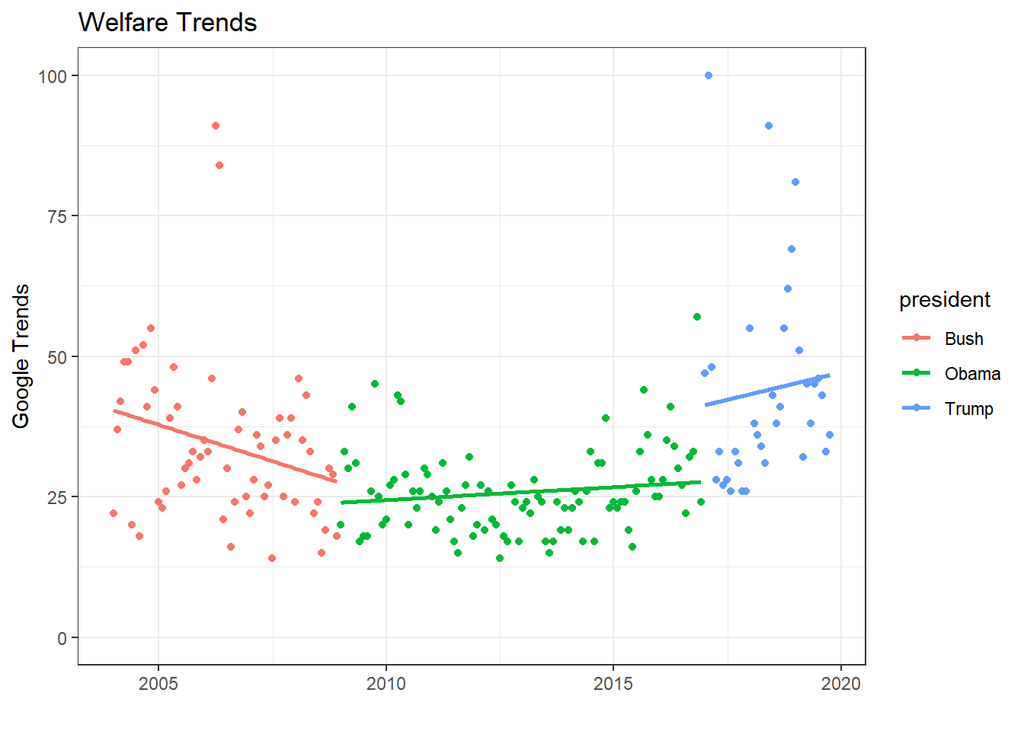

```r
#plotting welfare
trends_original  %>%
  ggplot(aes(x = date, y = welfare, color =  president), group_by = president) +
  geom_point() + geom_smooth(method = "lm", se = FALSE) +
  ylab("Google Trends") + xlab("") + scale_y_continuous(limits = c(0, 100)) +
  ggtitle("Welfare Trends")
```

## Figure 4 Report:

> When replicating Figure 4 using the orignal dataset, we got near identical results. However, when replicating with the 2024 Google Trends data, we noticed a lot of zero values that weren’t present in the original dataset for the paper. This resulted in slightly skewed regression lines for the Bush administration. We suspect that maybe Google Trends dropped the data for those specific days.

# Table 3 Replication: Regression Model using Google Trends data

## Replication of Table 3 using 2024 Google Trends Data

```r
#Crime
google_trends_2024$president <- relevel(factor(google_trends_2024$president), ref = "Obama")

crime_regression <- lm(crime ~ ym + president , data = google_trends_2024)

print("Crime_Regression")
```

```
## [1] "Crime_Regression"
```

```r
summary(crime_regression)
```

```
##
## Call:
## lm(formula = crime ~ ym + president, data = google_trends_2024)
##
## Residuals:
##     Min      1Q  Median      3Q     Max
## -13.508  -4.959  -2.184   3.035  37.960
##
## Coefficients:
##                  Estimate Std. Error t value Pr(>|t|)
## (Intercept)    -3.160e+01  1.367e+01  -2.312  0.02188 *
## ym              2.584e-03  8.696e-04   2.971  0.00336 **
## presidentBush   3.179e+00  2.465e+00   1.290  0.19867
## presidentTrump  7.206e+00  2.368e+00   3.043  0.00268 **
## ---
## Signif. codes:  0 '***' 0.001 '**' 0.01 '*' 0.05 '.' 0.1 ' ' 1
##
## Residual standard error: 8.183 on 188 degrees of freedom
## Multiple R-squared:  0.3324, Adjusted R-squared:  0.3218
## F-statistic: 31.21 on 3 and 188 DF,  p-value: < 2.2e-16
```

```r
report_regression <- lm(report ~ ym + president , data = google_trends_2024)
print("Report_Regression")
```

```
## [1] "Report_Regression"
```

```r
summary(report_regression)
```

```
##
## Call:
## lm(formula = report ~ ym + president, data = google_trends_2024)
##
## Residuals:
##     Min      1Q  Median      3Q     Max
## -47.959  -5.455  -0.649   4.599  42.899
##
## Coefficients:
##                 Estimate Std. Error t value Pr(>|t|)
## (Intercept)    70.042554  17.008321   4.118 5.72e-05 ***
## ym             -0.001700   0.001082  -1.571    0.118
## presidentBush  -0.976845   3.067040  -0.318    0.750
## presidentTrump 16.289312   2.946926   5.528 1.07e-07 ***
## ---
## Signif. codes:  0 '***' 0.001 '**' 0.01 '*' 0.05 '.' 0.1 ' ' 1
##
## Residual standard error: 10.18 on 188 degrees of freedom
## Multiple R-squared:  0.1911, Adjusted R-squared:  0.1782
## F-statistic:  14.8 on 3 and 188 DF,  p-value: 1.081e-08
```

```r
welfare_regression <- lm(welfare ~ ym + president, data = google_trends_2024)
print("Welfare_Regression")
```

```
## [1] "Welfare_Regression"
```

```r
summary(welfare_regression)
```

```
##
## Call:
## lm(formula = welfare ~ ym + president, data = google_trends_2024)
##
## Residuals:
##      Min       1Q   Median       3Q      Max
## -11.0316  -3.7726  -0.3853   2.6861  27.3412
##
## Coefficients:
##                  Estimate Std. Error t value Pr(>|t|)
## (Intercept)    -1.067e+01  1.171e+01  -0.910   0.3638
## ym              1.408e-03  7.452e-04   1.889   0.0604 .
## presidentBush   1.682e+00  2.112e+00   0.796   0.4268
## presidentTrump  4.744e+00  2.030e+00   2.337   0.0205 *
## ---
## Signif. codes:  0 '***' 0.001 '**' 0.01 '*' 0.05 '.' 0.1 ' ' 1
##
## Residual standard error: 7.013 on 188 degrees of freedom
## Multiple R-squared:  0.1957, Adjusted R-squared:  0.1829
## F-statistic: 15.25 on 3 and 188 DF,  p-value: 6.391e-09
```

## Replication of Table 3 using the Original Dataset

```r
#Crime
trends_original$president <- relevel(factor(trends_original$president), ref = "Obama")

crime_regression <- lm(crime ~ date + president , data = trends_original)
print("Crime_Regression")
```

```
## [1] "Crime_Regression"
```

```r
summary(crime_regression)
```

```
##
## Call:
## lm(formula = crime ~ date + president, data = trends_original)
##
## Residuals:
##     Min      1Q  Median      3Q     Max
## -21.480  -6.927  -3.641   3.294  62.821
##
## Coefficients:
##                 Estimate Std. Error t value Pr(>|t|)
## (Intercept)    -4.163158  23.241077  -0.179   0.8580
## date            0.001247   0.001479   0.843   0.4002
## presidentBush   8.280386   4.187005   1.978   0.0494 *
## presidentTrump 19.902636   4.027082   4.942 1.72e-06 ***
## ---
## Signif. codes:  0 '***' 0.001 '**' 0.01 '*' 0.05 '.' 0.1 ' ' 1
##
## Residual standard error: 13.87 on 186 degrees of freedom
## Multiple R-squared:  0.2621, Adjusted R-squared:  0.2502
## F-statistic: 22.03 on 3 and 186 DF,  p-value: 2.988e-12
```

```r
report_regression <- lm(report ~ date + president , data = trends_original)
print("Report_Regression")
```

```
## [1] "Report_Regression"
```

```r
summary(report_regression)
```

```
##
## Call:
## lm(formula = report ~ date + president, data = trends_original)
##
## Residuals:
##     Min      1Q  Median      3Q     Max
## -22.050  -5.662  -1.293   4.796  38.482
##
## Coefficients:
##                 Estimate Std. Error t value Pr(>|t|)
## (Intercept)    72.573674  16.089215   4.511 1.14e-05 ***
## date           -0.001789   0.001024  -1.748   0.0821 .
## presidentBush   0.785389   2.898559   0.271   0.7867
## presidentTrump 19.716343   2.787848   7.072 2.99e-11 ***
## ---
## Signif. codes:  0 '***' 0.001 '**' 0.01 '*' 0.05 '.' 0.1 ' ' 1
##
## Residual standard error: 9.601 on 186 degrees of freedom
## Multiple R-squared:  0.2863, Adjusted R-squared:  0.2748
## F-statistic: 24.87 on 3 and 186 DF,  p-value: 1.411e-13
```

```r
welfare_regression <- lm(welfare ~ date + president, data = trends_original)
print("Welfare_Regression")
```

```
## [1] "Welfare_Regression"
```

```r
summary(welfare_regression)
```

```
##
## Call:
## lm(formula = welfare ~ date + president, data = trends_original)
##
## Residuals:
##     Min      1Q  Median      3Q     Max
## -19.966  -7.986  -1.646   4.774  56.953
##
## Coefficients:
##                 Estimate Std. Error t value Pr(>|t|)
## (Intercept)    28.584544  20.709656   1.380   0.1692
## date           -0.000178   0.001318  -0.135   0.8927
## presidentBush   7.819065   3.730956   2.096   0.0375 *
## presidentTrump 18.560493   3.588452   5.172 5.95e-07 ***
## ---
## Signif. codes:  0 '***' 0.001 '**' 0.01 '*' 0.05 '.' 0.1 ' ' 1
##
## Residual standard error: 12.36 on 186 degrees of freedom
## Multiple R-squared:  0.237,  Adjusted R-squared:  0.2247
## F-statistic: 19.26 on 3 and 186 DF,  p-value: 6.428e-11
```

## Table 3 Report:

> When we replicated Table 3 using the original data set, we got near identical results. However, when we tried to replicate Table 3 using the 2024 Google Trends data, only the “report trends” table had close results to the paper. The other two (welfare and crime) had drastically different coefficients, although the p-values are similar. This is most likely due to the effects of the extra zero values.

# Figure 2-3 Replication: News Coverage data by News Channel, split by Trump’s Campaign Period

## Replication of Figure 2 using the Original Topic Model

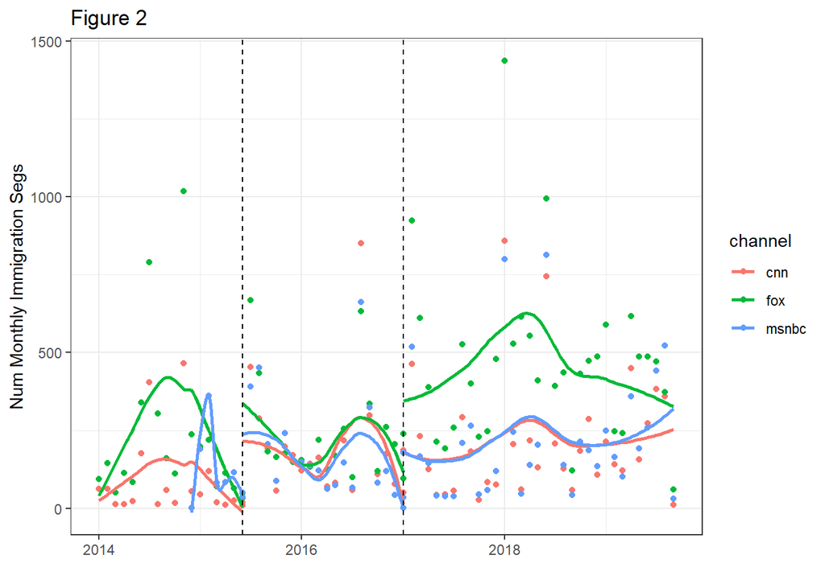

```r
document_topics %>%
  mutate( ym = ym(format(ymd(date), "%Y-%m"))) %>%
  group_by(channel, ym, post_election, post_trump, time ) %>%
  summarize( total_duration = sum(duration)) %>%
  ggplot(aes(x = ym, y = total_duration, color = channel, group = interaction(channel, time))) +
  geom_point() +
  geom_smooth( se = F) +
  geom_vline(xintercept = c(ym("2015-06"), ym("2017-01")), linetype = "dashed") +
  ggtitle("Figure 2") +
  ylab("Num Monthly Immigration Segs") +
  xlab("")
```

## Replication of Figure 3 using the Original Topic Model

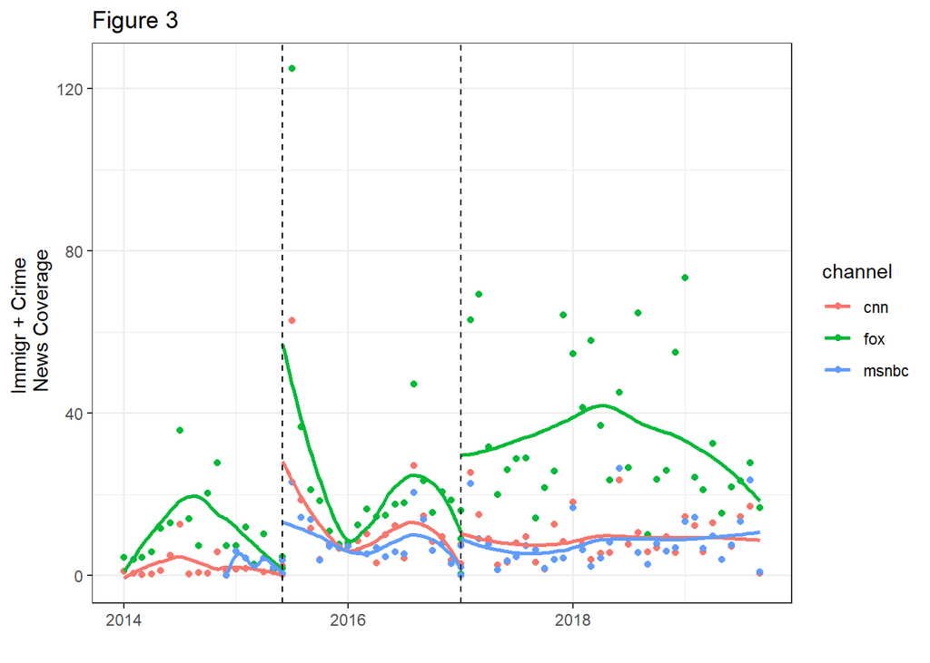

```r
document_topics %>%
  select(Topic1, Topic3, channel, date, duration, post_election, post_trump, time) %>%
  mutate(Topic  = Topic1 +  Topic3)%>%
  mutate( ym = ym(format(ymd(date), "%Y-%m"))) %>%
  group_by(channel, ym, post_election, post_trump, time ) %>%
  summarize( total_duration = sum(Topic)) %>%
  ggplot(aes(x = ym, y = total_duration, color = channel, group = interaction(channel, time))) +
  geom_point() +
  geom_smooth( se = F) +
  geom_vline(xintercept = c(ym("2015-06"), ym("2017-01")), linetype = "dashed") +
  ylab("Immigr + Crime \n News Coverage") +
  xlab("") +
  ggtitle("Figure 3")
```

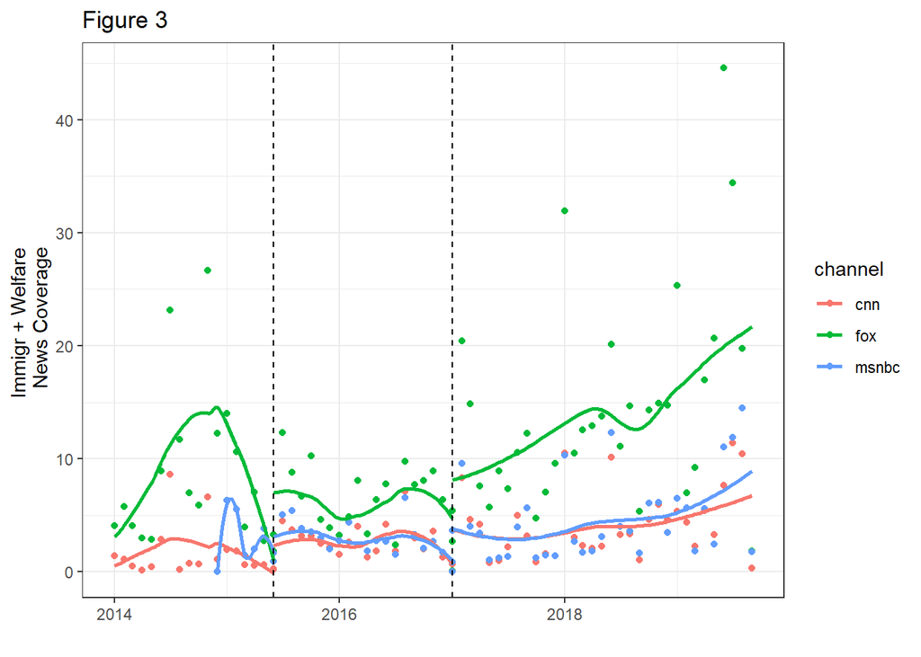

```r
document_topics %>%
  select(Topic13, channel, date, duration, post_election, post_trump, time) %>%
  mutate( ym = ym(format(ymd(date), "%Y-%m"))) %>%
  group_by(channel, ym, post_election, post_trump, time ) %>%
  summarize( total_duration = sum(Topic13)) %>%
  ggplot(aes(x = ym, y = total_duration, color = channel, group = interaction(channel, time))) +
  geom_point() +
  geom_smooth( se = F) +
  geom_vline(xintercept = c(ym("2015-06"), ym("2017-01")), linetype = "dashed")+
  ylab("Immigr + Welfare \n News Coverage") +
  xlab("") +
  ggtitle("Figure 3")
```

## Figure 2-3 Report:

> Using the topic model data used by the research paper, we were able to make near identical graphs.

# Table 4 Replication: Regression Model using News Coverage and Google Trends Data

## Replication of Table 4 using Daily Topic Model and Google Trends data

```r
immig_segment <- document_topics %>%
  mutate( ymd = ymd(format(ymd(date), "%Y-%m-%d"))) %>%
  group_by(ymd) %>%
  summarize( segment = sum(duration))

immig_crime <- document_topics %>%
  select(Topic1, Topic3, date) %>%
  mutate(Topic  = Topic1 +  Topic3)%>%
  mutate( ymd = ymd(format(ymd(date), "%Y-%m-%d"))) %>%
  group_by(ymd) %>%
  summarize( crime = sum(Topic))

immig_welfare <- document_topics %>%
  select(Topic13, channel, date, duration, post_election, post_trump, time) %>%
  mutate( ymd = ymd(format(ymd(date), "%Y-%m-%d"))) %>%
  group_by(ymd) %>%
  summarize( welfare = sum(Topic13))

immig_comb <- left_join(immig_crime, immig_segment, by = join_by(ymd)) %>%
  left_join(immig_welfare, by = join_by(ymd)) %>%
  mutate( Trump_admin = case_when(
    ymd("2017-01-01") < ymd ~ TRUE,
    .default = FALSE
  ), weekday = weekdays.Date(ymd), month = months.Date(ymd))
```

```r
# Merge all data frames together
table_4 <- inner_join(daily_report, immig_comb)

print("Search Data")
```

```
## [1] "Search Data"
```

```r
regression <- lm(search ~ ymd + crime + segment + welfare + Trump_admin + weekday + month, table_4)
summary(regression)
```

```
##
## Call:
## lm(formula = search ~ ymd + crime + segment + welfare + Trump_admin +
##     weekday + month, data = table_4)
##
## Residuals:
##     Min      1Q  Median      3Q     Max
## -47.254 -13.465  -1.511  11.179  62.069
##
## Coefficients:
##                   Estimate Std. Error t value Pr(>|t|)
## (Intercept)      77.908253  23.780954   3.276 0.001071 **
## ymd              -0.002196   0.001432  -1.534 0.125254
## crime             0.064368   0.261010   0.247 0.805233
## segment           0.047044   0.018910   2.488 0.012932 *
## welfare           1.523201   0.666820   2.284 0.022459 *
## Trump_adminTRUE   6.251839   1.692285   3.694 0.000226 ***
## weekdayMonday     1.568848   1.543870   1.016 0.309667
## weekdaySaturday  -3.043553   1.546315  -1.968 0.049175 *
## weekdaySunday    -4.889389   1.540464  -3.174 0.001526 **
## weekdayThursday   3.177135   1.540152   2.063 0.039253 *
## weekdayTuesday   -0.334169   1.538628  -0.217 0.828085
## weekdayWednesday  4.002338   1.537512   2.603 0.009306 **
## monthAugust      -1.545502   1.975488  -0.782 0.434107
## monthDecember     4.896784   2.089877   2.343 0.019222 *
## monthFebruary     1.574983   2.006999   0.785 0.432696
## monthJanuary     -1.247298   1.982518  -0.629 0.529324
## monthJuly         2.271054   1.977468   1.148 0.250913
## monthJune         3.280531   1.996264   1.643 0.100470
## monthMarch       -6.166266   1.978310  -3.117 0.001853 **
## monthMay         -0.207390   1.975072  -0.105 0.916383
## monthNovember     2.160816   2.080258   1.039 0.299058
## monthOctober     -0.652621   2.071266  -0.315 0.752731
## monthSeptember   -0.635930   2.041850  -0.311 0.755492
## ---
## Signif. codes:  0 '***' 0.001 '**' 0.01 '*' 0.05 '.' 0.1 ' ' 1
##
## Residual standard error: 18.55 on 2007 degrees of freedom
## Multiple R-squared:  0.08522,    Adjusted R-squared:  0.07519
## F-statistic: 8.499 on 22 and 2007 DF,  p-value: < 2.2e-16
```

```r
print("Search Adjusted Data")
```

```
## [1] "Search Adjusted Data"
```

```r
regression_adj <- lm(search_adj ~ ymd + crime + segment + welfare + Trump_admin + weekday + month, table_4)
summary(regression_adj)
```

```
##
## Call:
## lm(formula = search_adj ~ ymd + crime + segment + welfare + Trump_admin +
##     weekday + month, data = table_4)
##
## Residuals:
##     Min      1Q  Median      3Q     Max
## -46.311 -11.892  -1.991   8.933 138.084
##
## Coefficients:
##                   Estimate Std. Error t value Pr(>|t|)
## (Intercept)      98.707429  24.124352   4.092 4.45e-05 ***
## ymd              -0.003863   0.001453  -2.659 0.007901 **
## crime             0.728080   0.264779   2.750 0.006017 **
## segment           0.048404   0.019183   2.523 0.011701 *
## welfare           2.367886   0.676449   3.500 0.000475 ***
## Trump_adminTRUE  18.634297   1.716722  10.855  < 2e-16 ***
## weekdayMonday     0.605772   1.566164   0.387 0.698955
## weekdaySaturday  -3.815175   1.568644  -2.432 0.015096 *
## weekdaySunday    -5.312643   1.562708  -3.400 0.000688 ***
## weekdayThursday   2.510494   1.562391   1.607 0.108249
## weekdayTuesday   -1.210984   1.560845  -0.776 0.437928
## weekdayWednesday  2.953994   1.559714   1.894 0.058378 .
## monthAugust       0.365126   2.004014   0.182 0.855446
## monthDecember     1.895632   2.120055   0.894 0.371353
## monthFebruary    11.327658   2.035980   5.564 2.99e-08 ***
## monthJanuary     10.715976   2.011146   5.328 1.10e-07 ***
## monthJuly         1.187310   2.006022   0.592 0.554002
## monthJune         3.963759   2.025091   1.957 0.050448 .
## monthMarch        2.839990   2.006877   1.415 0.157186
## monthMay          0.134669   2.003592   0.067 0.946418
## monthNovember     1.278942   2.110297   0.606 0.544551
## monthOctober     -1.438794   2.101176  -0.685 0.493576
## monthSeptember   -0.547946   2.071334  -0.265 0.791393
## ---
## Signif. codes:  0 '***' 0.001 '**' 0.01 '*' 0.05 '.' 0.1 ' ' 1
##
## Residual standard error: 18.82 on 2007 degrees of freedom
## Multiple R-squared:  0.2591, Adjusted R-squared:  0.251
## F-statistic: 31.91 on 22 and 2007 DF,  p-value: < 2.2e-16
```

## Table 4 Report:

> We replicated a regression analysis on both for predicting the standard Google Trends “Reporting” data and the adjusted Google Trends “Reporting” data (adj = monthly search / mean weekly search). We found that by using the adjusted data, we got similar outcomes, particularly for the “Trump_admin” feature (18.634301), but the intercept seems to be different. When running on the standard data, the intercept is closer to the reported table, but the “Trump_admin” feature is drastically lower (6.251847). However, the p-values replicated are similar, so there does seem to be a correlation between the Trump administration and the search data.

# Extension:

## Question 1:

> The paper uses “Trump’s Presidential Term” as an indicator for “government support for deportation.” The analysis from this decision supports Hypothesis 1 of this paper: “People will have more interest in reporting immigrants when they believe the government supports deportation.” However, perhaps a better metric to use would be the passage of specific immigration based policies. By identifying positive and negative key immigration policies passed and the exact day of passage, we can explore the reaction of the “reporting”, “welfare”, and “crime” search data.

## Question 2:

> Investigating further for Hypothesis 1: “H1: People will have more interest in reporting immigrants when they believe the government supports deportation.” Table 5 supported H1 by stating that “Regarding Trump’s campaign cues, the regressions did not show a significant positive effect of Trump’s immigration coverage on anti-immigrant searches during the campaign. However, the cues about Trump’s presidential immigration policy positively and significantly affected reporting searches. Both of these findings provide further support for Hypothesis 1.”

> But we thought that not just because of government supports, there is an increase in interest in reporting immigrants, but also it is because there is more news activity during Trump presidential. Therefore we thought it is worth to explore further by adjusting report search by the total number of news streamed. (#time interval we chose “monthly adjustment”)

### Replication of Table 5 using Original Topic Model and Original Dataset

```r
#Importing Trump segments and monthly adjustment
trump_segs <- document_topics %>%
  select(date, trump) %>%
  mutate( ymd = ymd(format(ymd(date), "%Y-%m-%d"))) %>%
  group_by(ymd) %>%
  summarize( trump = sum(trump), count = n()) %>% mutate(ym = format(ymd, "%Y-%m")) %>% group_by(ym) %>%  mutate( max = cumsum(count), max = max(max))
table_5 <- inner_join(table_4, trump_segs) %>% mutate(news_adjust = search_adj / max)
```

```
## [1] "Replicating Table 5"
```

```
##
## Call:
## lm(formula = search_adj ~ segment + trump + Trump_admin + Trump_admin *
##     trump + crime + welfare + ymd + weekday + month, data = table_5)
##
## Residuals:
##     Min      1Q  Median      3Q     Max
## -49.145 -11.762  -2.061   8.958 139.752
##
## Coefficients:
##                         Estimate Std. Error t value Pr(>|t|)
## (Intercept)           91.1603546 24.8416056   3.670 0.000249 ***
## segment                0.0008597  0.0322341   0.027 0.978725
## trump                 -0.0286036  0.0555613  -0.515 0.606742
## Trump_adminTRUE       15.9952046  1.8499136   8.646  < 2e-16 ***
## crime                  0.8680465  0.2674561   3.246 0.001191 **
## welfare                2.0377912  0.6873738   2.965 0.003066 **
## ymd                   -0.0033704  0.0014955  -2.254 0.024324 *
## weekdayMonday          0.5685343  1.5607108   0.364 0.715688
## weekdaySaturday       -3.9442121  1.5625361  -2.524 0.011672 *
## weekdaySunday         -5.4298245  1.5569654  -3.487 0.000498 ***
## weekdayThursday        2.6148097  1.5561924   1.680 0.093062 .
## weekdayTuesday        -1.3198180  1.5547484  -0.849 0.396041
## weekdayWednesday       3.0430072  1.5535500   1.959 0.050281 .
## monthAugust            1.4808775  2.0179881   0.734 0.463133
## monthDecember          2.1738161  2.1136517   1.028 0.303855
## monthFebruary         11.2646437  2.0277062   5.555 3.14e-08 ***
## monthJanuary          10.4765642  2.0037581   5.228 1.89e-07 ***
## monthJuly              1.9820603  2.0088748   0.987 0.323932
## monthJune              3.9985449  2.0168297   1.983 0.047550 *
## monthMarch             3.2650911  2.0011768   1.632 0.102924
## monthMay               0.6076047  1.9984211   0.304 0.761127
## monthNovember          2.1050647  2.1148171   0.995 0.319667
## monthOctober          -1.1940365  2.0935285  -0.570 0.568507
## monthSeptember         0.2375459  2.0712677   0.115 0.908705
## trump:Trump_adminTRUE  0.2655726  0.0618434   4.294 1.84e-05 ***
## ---
## Signif. codes:  0 '***' 0.001 '**' 0.01 '*' 0.05 '.' 0.1 ' ' 1
##
## Residual standard error: 18.74 on 2005 degrees of freedom
## Multiple R-squared:  0.2659, Adjusted R-squared:  0.2571
## F-statistic: 30.26 on 24 and 2005 DF,  p-value: < 2.2e-16
```

```
## [1] "Adjusted Report Data by total number of segmens in a month"
```

```
##
## Call:
## lm(formula = news_adjust ~ segment + trump + Trump_admin + Trump_admin *
##     trump + crime + welfare + ymd + weekday + month, data = table_5)
##
## Residuals:
##      Min       1Q   Median       3Q      Max
## -0.13917 -0.03848 -0.00955  0.02350  0.36383
##
## Coefficients:
##                         Estimate Std. Error t value Pr(>|t|)
## (Intercept)            1.495e+00  7.882e-02  18.962  < 2e-16 ***
## segment               -5.257e-04  1.023e-04  -5.140 3.01e-07 ***
## trump                  2.116e-04  1.763e-04   1.201  0.23007
## Trump_adminTRUE        5.544e-02  5.870e-03   9.445  < 2e-16 ***
## crime                  4.918e-04  8.486e-04   0.580  0.56226
## welfare                2.773e-03  2.181e-03   1.271  0.20379
## ymd                   -8.287e-05  4.745e-06 -17.464  < 2e-16 ***
## weekdayMonday          2.784e-03  4.952e-03   0.562  0.57406
## weekdaySaturday       -8.386e-03  4.958e-03  -1.692  0.09088 .
## weekdaySunday         -9.050e-03  4.940e-03  -1.832  0.06710 .
## weekdayThursday        5.514e-03  4.938e-03   1.117  0.26425
## weekdayTuesday         2.611e-03  4.933e-03   0.529  0.59664
## weekdayWednesday       8.408e-03  4.929e-03   1.706  0.08823 .
## monthAugust           -3.671e-02  6.403e-03  -5.733 1.14e-08 ***
## monthDecember         -2.001e-02  6.706e-03  -2.983  0.00289 **
## monthFebruary         -3.008e-02  6.434e-03  -4.676 3.12e-06 ***
## monthJanuary          -2.981e-02  6.358e-03  -4.688 2.94e-06 ***
## monthJuly             -3.942e-02  6.374e-03  -6.184 7.55e-10 ***
## monthJune             -2.574e-02  6.399e-03  -4.022 5.99e-05 ***
## monthMarch             1.257e-02  6.350e-03   1.980  0.04780 *
## monthMay               1.593e-02  6.341e-03   2.513  0.01206 *
## monthNovember         -3.963e-02  6.710e-03  -5.905 4.12e-09 ***
## monthOctober           1.911e-03  6.643e-03   0.288  0.77362
## monthSeptember         9.896e-03  6.572e-03   1.506  0.13227
## trump:Trump_adminTRUE  3.864e-04  1.962e-04   1.969  0.04907 *
## ---
## Signif. codes:  0 '***' 0.001 '**' 0.01 '*' 0.05 '.' 0.1 ' ' 1
##
## Residual standard error: 0.05946 on 2005 degrees of freedom
## Multiple R-squared:  0.3066, Adjusted R-squared:  0.2983
## F-statistic: 36.93 on 24 and 2005 DF,  p-value: < 2.2e-16
```